# C. difficile infection in England

Descriptive surveillance of UKHSA monthly mandatory reporting, April 2019 onwards

Payton Yau

28 October 2026

## Summary

17,311

cases, last 12 months

+22.9%

vs pre-COVID baseline (monthly mean)

1,579

cases in Aug 2026 (provisional)

149

NHS acute trusts in the series

- **Time span.** 89 months, April 2019 to August 2026, from 149 NHS acute trusts in England.
- **Level.** The last 12 months averaged **1,443 cases per month**, 22.9% above the pre-COVID baseline of 1,174 per month. The series peaked in August 2024 (1,848 cases).
- **Unusual months.** 5 months exceeded the rolling negative binomial upper limit and 14 months were flagged by at least one of three methods. Flags are prompts to look, not outbreak declarations.
- **Limits of these data.** Counts are not rates: no bed-day denominator is published alongside them, so trusts and regions are compared with their own history, never ranked against each other. The latest months are provisional and are routinely revised (see *Data quality*).

## Data and methods

**Source.** UKHSA, *C. difficile infection: monthly data by prior trust exposure* (accredited official statistics), Open Government Licence v3.0. Each monthly release is a rolling 13-month file of counts per NHS organisation and onset category, for patients aged 2 and over. The series here starts in April 2019, when the prior-trust-exposure case definitions began; earlier files are not comparable and are not used.

**Assembling one series from many files.** Releases overlap, so each organisation-month is taken from the most recent release that contains it. Differences between releases are measured, not discarded (*Data quality*). The same cases are published under three geographies (NHS acute trust, Sub-ICB, England); this report uses the trust rows only, because summing geographies would double-count.

**Onset categories.** Cases are classified by where infection began and its healthcare association: hospital-onset healthcare-associated (HOHA), community-onset healthcare-associated (COHA), community-onset indeterminate (COIA), community-onset community-associated (COCA), plus a small number with unknown or missing information. Cases are attributed to the trust whose laboratory processed the specimen, which may not be where the infection was acquired.

**Exceedance.** Three simple baselines are compared, each using only information available before the month in question: (1) the mean plus two standard deviations of all earlier months; (2) EARS C2, the mean plus three standard deviations of a seven-month baseline that ends three months earlier; (3) a rolling negative binomial regression with a linear trend and an annual harmonic, fitted to the previous 36 months with the COVID-19 disruption window left out, flagging counts above its 97.5th percentile.

## Trend

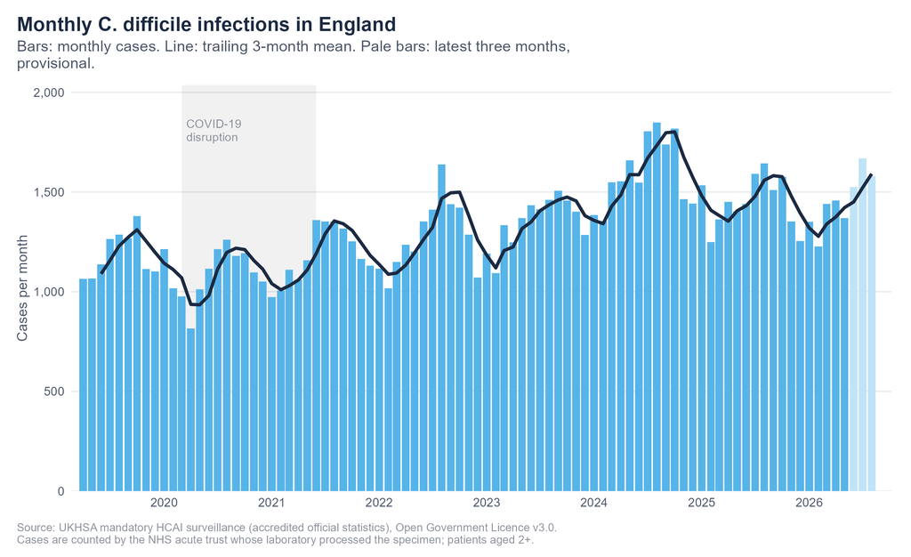

Cases by NHS financial year (April to March). Percentages show change on the previous complete year. * = incomplete year.

| Financial year | All cases | Hospital-onset, healthcare-associated | Community-onset, healthcare-associated | Community-onset, indeterminate | Community-onset, community-associated |
| --- | --- | --- | --- | --- | --- |
| 2019/20 | 13,890 | 5,586 | 2,586 | 1,609 | 4,053 |
| 2020/21 | 13,028 (-6.2%) | 5,075 (-9.1%) | 2,301 (-11.0%) | 1,493 (-7.2%) | 4,133 (+2.0%) |
| 2021/22 | 14,426 (+10.7%) | 6,094 (+20.1%) | 2,458 (+6.8%) | 1,601 (+7.2%) | 4,238 (+2.5%) |
| 2022/23 | 15,677 (+8.7%) | 7,232 (+18.7%) | 2,553 (+3.9%) | 1,554 (-2.9%) | 4,307 (+1.6%) |
| 2023/24 | 16,863 (+7.6%) | 7,549 (+4.4%) | 2,830 (+10.8%) | 1,752 (+12.7%) | 4,699 (+9.1%) |
| 2024/25 | 19,022 (+12.8%) | 8,457 (+12.0%) | 3,316 (+17.2%) | 1,928 (+10.0%) | 5,307 (+12.9%) |
| 2025/26 | 17,242 (-9.4%) | 7,404 (-12.5%) | 3,042 (-8.3%) | 1,849 (-4.1%) | 4,943 (-6.9%) |
| 2026/27 | 7,599 * | 3,175 * | 1,404 * | 820 * | 2,199 * |

## Where infections start

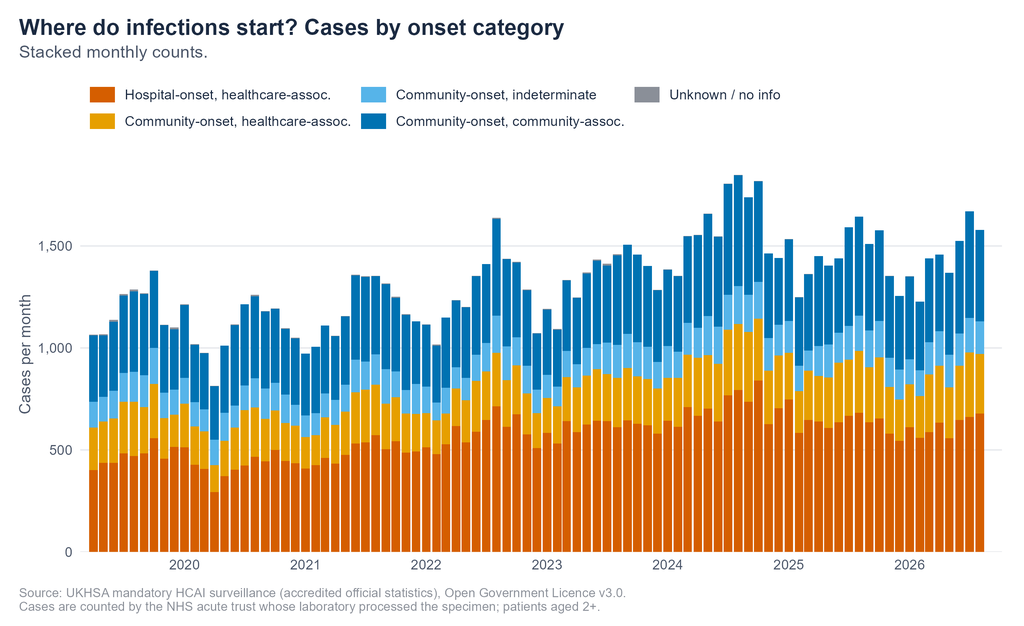

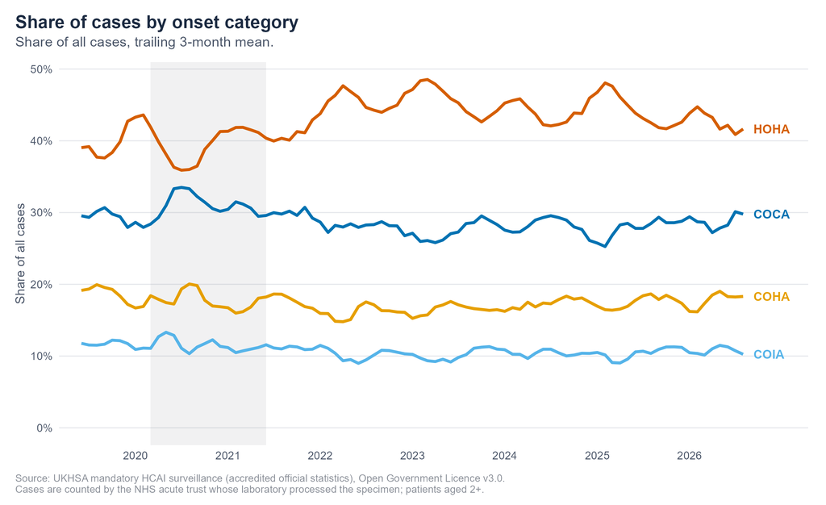

## Seasonality

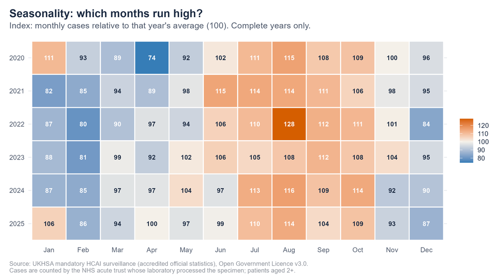

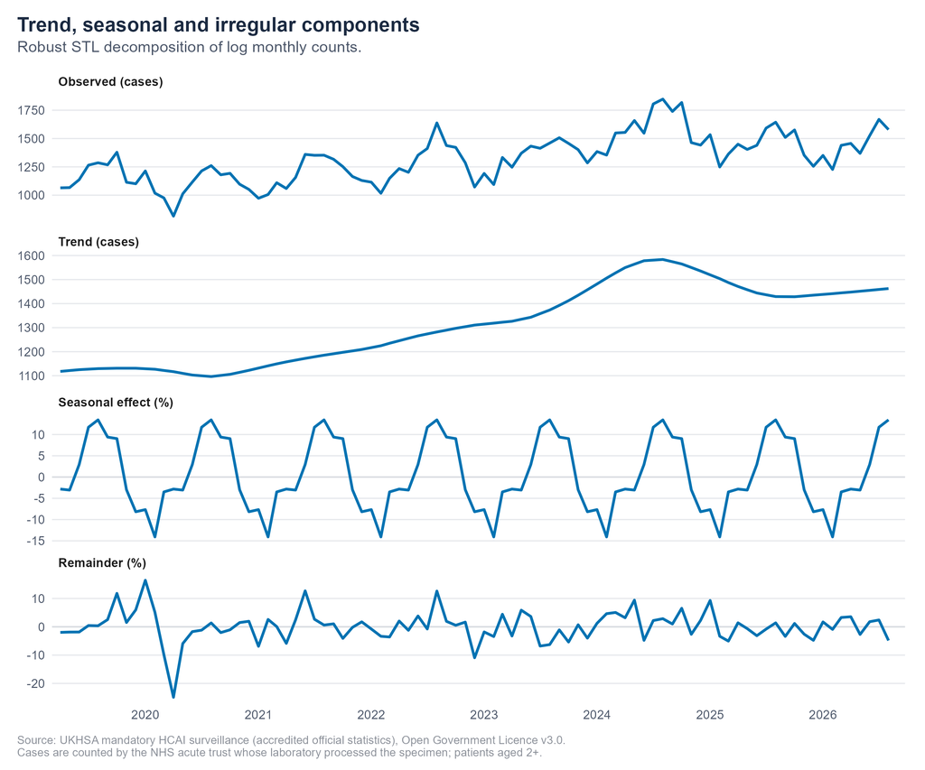

## Regions and trusts

Counts depend on how large a trust or region is, so these figures compare each with **its own** pre-COVID baseline rather than with each other.

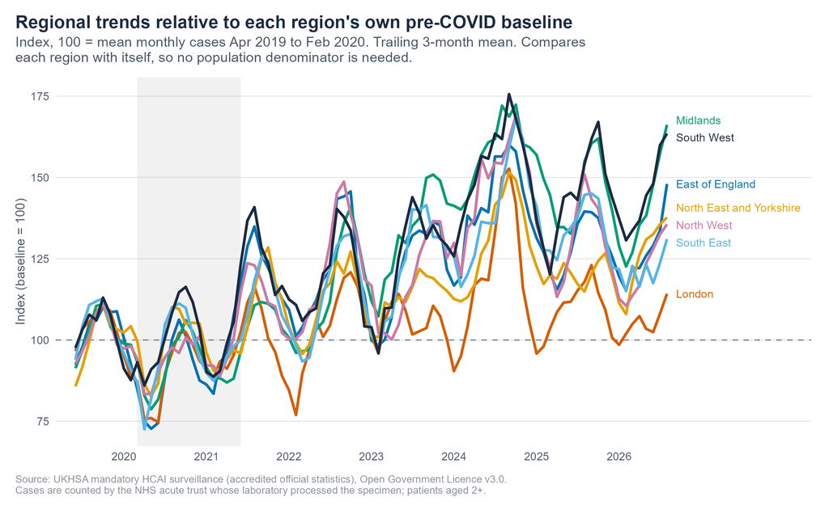

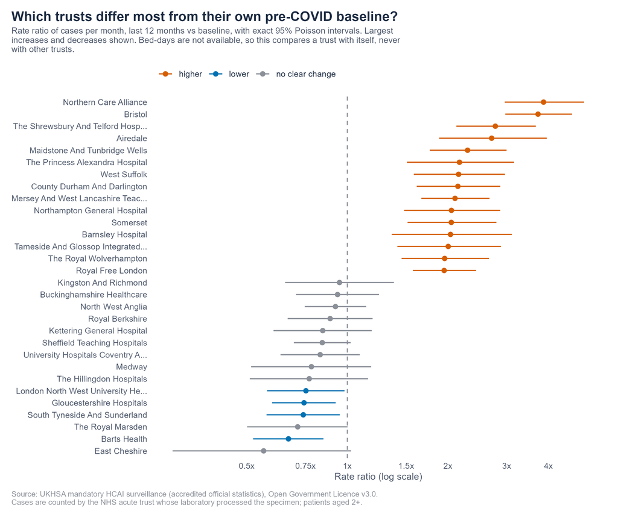

Trusts furthest above and below their own baseline. Rate ratio = cases per month in the last 12 months divided by cases per month in the baseline period.

| Trust | Region | Baseline cases/month | Last 12 months cases/month | Rate ratio (95% CI) |
| --- | --- | --- | --- | --- |
| Northern Care Alliance | North West | 6.2 | 23.9 | 3.87 (2.96 to 5.12) |
| Bristol | South West | 8.7 | 32.5 | 3.72 (2.97 to 4.71) |
| The Shrewsbury And Telford Hosp… | Midlands | 6.6 | 18.4 | 2.78 (2.12 to 3.67) |
| Airedale | North East and Yorkshire | 3.7 | 10.1 | 2.71 (1.88 to 3.96) |
| Maidstone And Tunbridge Wells | South East | 7.5 | 17.1 | 2.29 (1.77 to 3.00) |
| The Princess Alexandra Hospital | East of England | 4.0 | 8.7 | 2.17 (1.51 to 3.16) |
| West Suffolk | East of England | 5.5 | 11.8 | 2.15 (1.58 to 2.96) |
| County Durham And Darlington | North East and Yorkshire | 6.5 | 13.8 | 2.14 (1.61 to 2.87) |
| Mersey And West Lancashire Teac… | North West | 9.6 | 20.2 | 2.10 (1.67 to 2.67) |
| Northampton General Hospital | Midlands | 5.0 | 10.2 | 2.05 (1.48 to 2.87) |
| Somerset | South West | 5.8 | 11.9 | 2.05 (1.52 to 2.80) |
| Barnsley Hospital | North East and Yorkshire | 3.3 | 6.7 | 2.04 (1.36 to 3.11) |
| Royal Berkshire | South East | 8.9 | 7.9 | 0.89 (0.66 to 1.19) |
| Kettering General Hospital | Midlands | 6.9 | 5.8 | 0.84 (0.60 to 1.18) |
| Sheffield Teaching Hospitals | North East and Yorkshire | 20.0 | 16.8 | 0.84 (0.69 to 1.02) |
| University Hospitals Coventry A… | Midlands | 10.5 | 8.8 | 0.83 (0.63 to 1.09) |
| Medway | South East | 4.9 | 3.8 | 0.78 (0.52 to 1.18) |
| The Hillingdon Hospitals | London | 5.1 | 3.9 | 0.77 (0.51 to 1.15) |
| London North West University He… | London | 11.6 | 8.8 | 0.75 (0.58 to 0.98) |
| Gloucestershire Hospitals | South West | 17.2 | 12.8 | 0.74 (0.60 to 0.92) |
| South Tyneside And Sunderland | North East and Yorkshire | 13.1 | 9.7 | 0.74 (0.57 to 0.95) |
| The Royal Marsden | London | 7.3 | 5.2 | 0.71 (0.50 to 1.00) |
| Barts Health | London | 15.0 | 10.0 | 0.67 (0.52 to 0.85) |
| East Cheshire | North West | 2.8 | 1.6 | 0.56 (0.30 to 1.03) |

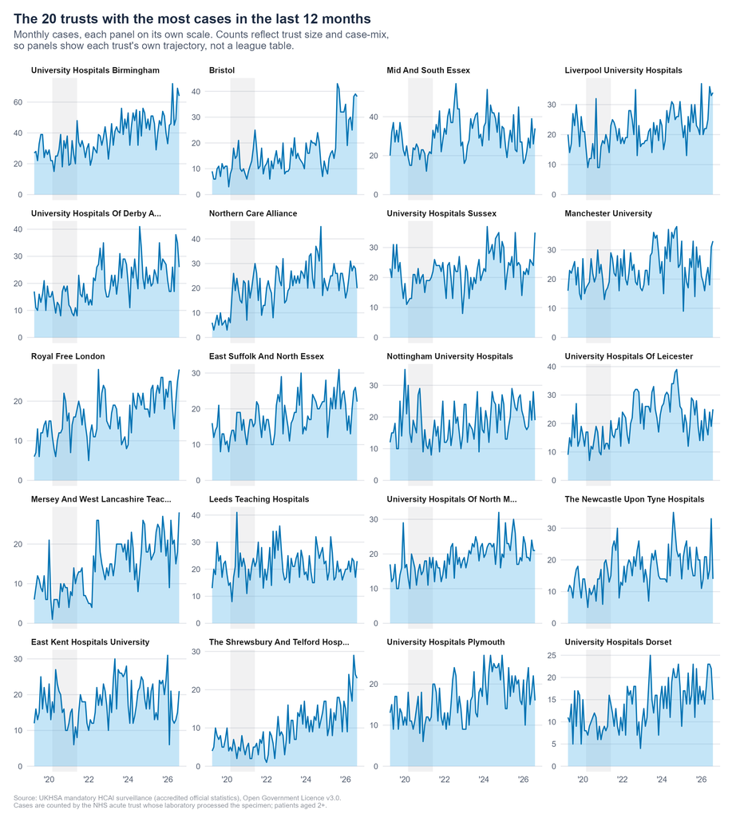

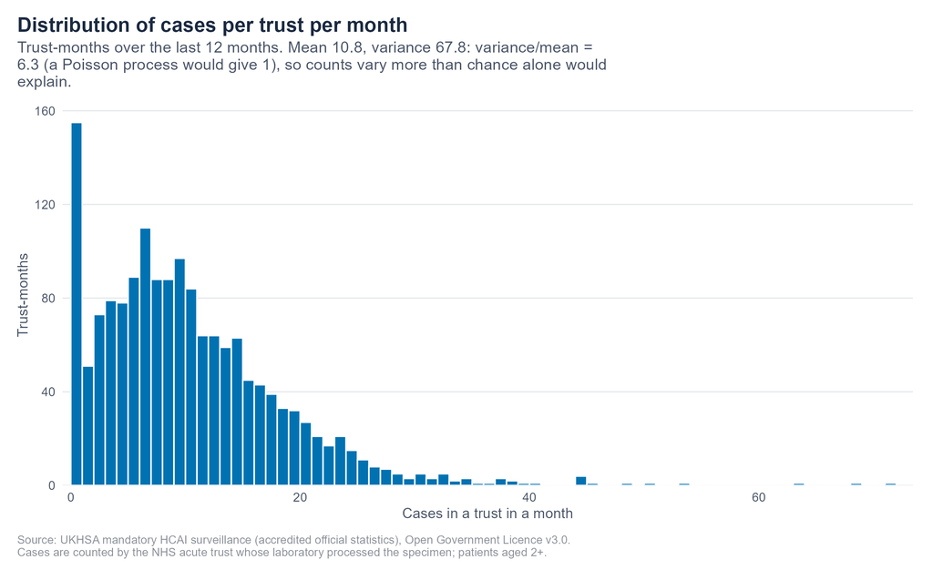

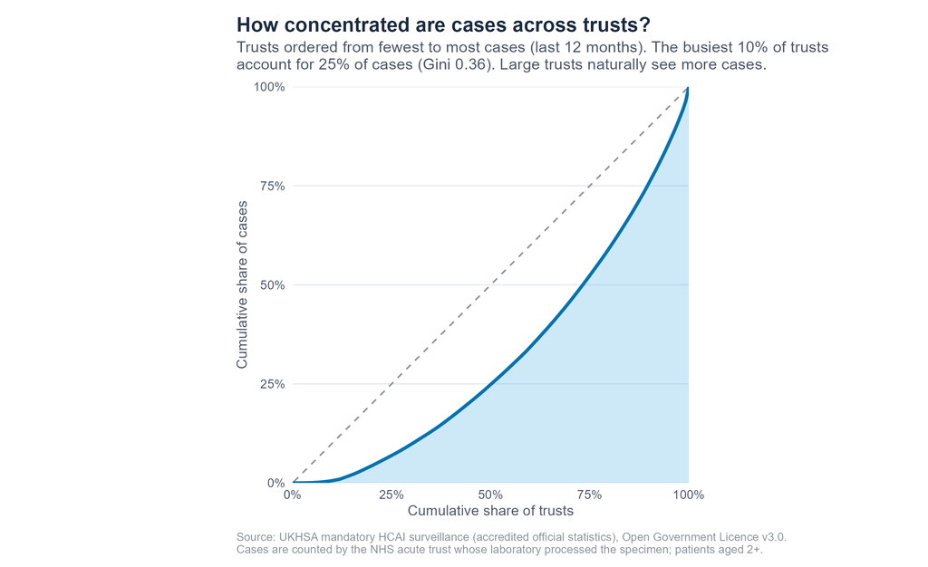

## Exceedance

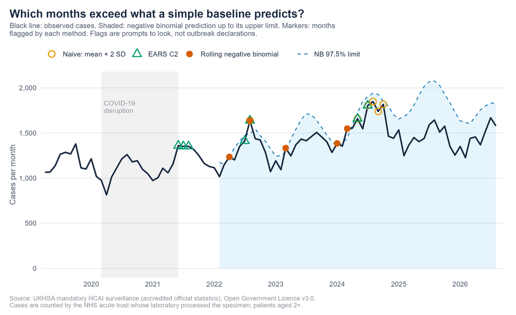

Flags by method (months with enough history only).

| Method | Months flagged | Outside COVID window | First flag | Last flag |
| --- | --- | --- | --- | --- |
| naive | 6 | 6 | 2022-08-01 | 2024-10-01 |
| ears | 7 | 6 | 2021-06-01 | 2024-07-01 |
| nb | 5 | 5 | 2022-04-01 | 2024-03-01 |

Months flagged by at least one method (most recent first).

| Month | Cases | Expected (NB) | NB limit | EARS limit | Naive limit | Methods | In COVID window | Provisional |
| --- | --- | --- | --- | --- | --- | --- | --- | --- |
| Oct 2024 | 1,818 | 1,659 | 1,852 | 2,013 | 1,693 | 1 |  |  |
| Sep 2024 | 1,739 | 1,725 | 1,927 | 1,882 | 1,672 | 1 |  |  |
| Aug 2024 | 1,848 | 1,739 | 1,941 | 1,856 | 1,639 | 1 |  |  |
| Jul 2024 | 1,805 | 1,705 | 1,903 | 1,726 | 1,607 | 2 |  |  |
| May 2024 | 1,659 | 1,546 | 1,725 | 1,631 | 1,576 | 2 |  |  |
| Mar 2024 | 1,549 | 1,309 | 1,445 | 1,632 | 1,550 | 1 |  |  |
| Jan 2024 | 1,385 | 1,235 | 1,355 | 1,666 | 1,546 | 1 |  |  |
| Mar 2023 | 1,333 | 1,179 | 1,288 | 1,890 | 1,489 | 1 |  |  |
| Aug 2022 | 1,638 | 1,368 | 1,494 | 1,354 | 1,430 | 3 |  |  |
| Jul 2022 | 1,412 | 1,349 | 1,474 | 1,388 | 1,414 | 1 |  |  |
| Apr 2022 | 1,235 | 1,114 | 1,226 | 1,552 | 1,405 | 1 |  |  |
| Aug 2021 | 1,353 |  |  | 1,253 | 1,402 | 1 |  |  |
| Jul 2021 | 1,352 |  |  | 1,287 | 1,386 | 1 |  |  |
| Jun 2021 | 1,360 |  |  | 1,336 | 1,364 | 1 | yes |  |

The three methods disagree on purpose: they answer slightly different questions, and their disagreement is information. A month flagged by all three deserves a look; a month flagged by one usually does not. Months inside the COVID-19 window, and the latest three months (provisional), should be read with extra caution.

## Data quality

Automated checks run on every build.

| Check | Problems | Result |
| --- | --- | --- |
| Layout: required columns present in every file | 0 | pass |
| No duplicate organisation-month-measure within a file | 0 | pass |
| Six components add up to the total | 0 | pass |
| Trust, Sub-ICB and National totals agree | 2 | FAIL |
| No month missing from the series | 0 | pass |
| No missing counts | 0 | pass |

### How much do published counts change?

Mandatory surveillance counts are revised as laboratories and trusts correct and complete their submissions. The figures below compare every release of a trust-month with its final published value.

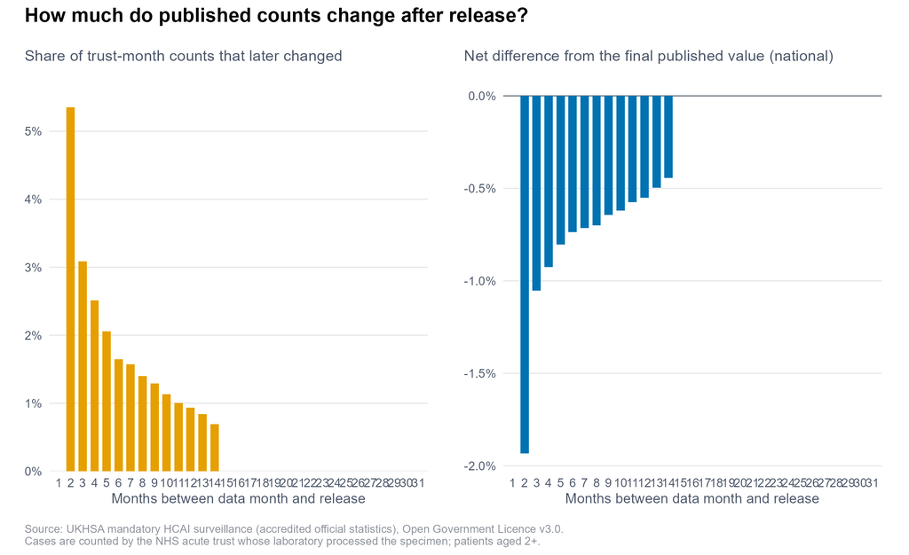

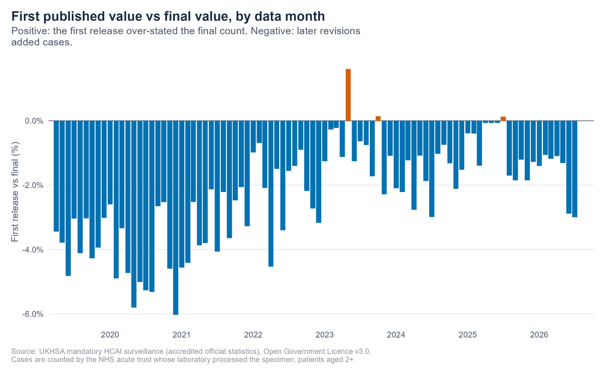

Revisions by release lag.

| Months after data month | Trust-months | % later revised | Mean abs. change (cases) | Net vs final |
| --- | --- | --- | --- | --- |
| 2 | 10553 | 5.4% | 0.23 | -1.93% |
| 3 | 10553 | 3.1% | 0.13 | -1.05% |
| 4 | 10553 | 2.5% | 0.11 | -0.92% |
| 5 | 10553 | 2.1% | 0.10 | -0.80% |
| 6 | 10553 | 1.6% | 0.08 | -0.74% |
| 7 | 10553 | 1.6% | 0.08 | -0.71% |
| 8 | 10553 | 1.4% | 0.08 | -0.70% |
| 9 | 10689 | 1.3% | 0.07 | -0.64% |
| 10 | 10689 | 1.1% | 0.07 | -0.62% |
| 11 | 10824 | 1.0% | 0.06 | -0.58% |
| 12 | 10824 | 0.9% | 0.06 | -0.55% |
| 13 | 10962 | 0.8% | 0.05 | -0.50% |
| 14 | 10962 | 0.7% | 0.04 | -0.44% |
| 15 | 409 | 0.0% | 0.00 | +0.00% |
| 16 | 409 | 0.0% | 0.00 | +0.00% |
| 17 | 409 | 0.0% | 0.00 | +0.00% |
| 18 | 409 | 0.0% | 0.00 | +0.00% |
| 19 | 548 | 0.0% | 0.00 | +0.00% |
| 20 | 548 | 0.0% | 0.00 | +0.00% |
| 21 | 412 | 0.0% | 0.00 | +0.00% |
| 22 | 412 | 0.0% | 0.00 | +0.00% |
| 23 | 277 | 0.0% | 0.00 | +0.00% |
| 24 | 277 | 0.0% | 0.00 | +0.00% |
| 25 | 139 | 0.0% | 0.00 | +0.00% |
| 26 | 139 | 0.0% | 0.00 | +0.00% |
| 27 | 139 | 0.0% | 0.00 | +0.00% |
| 28 | 139 | 0.0% | 0.00 | +0.00% |
| 29 | 139 | 0.0% | 0.00 | +0.00% |
| 30 | 139 | 0.0% | 0.00 | +0.00% |

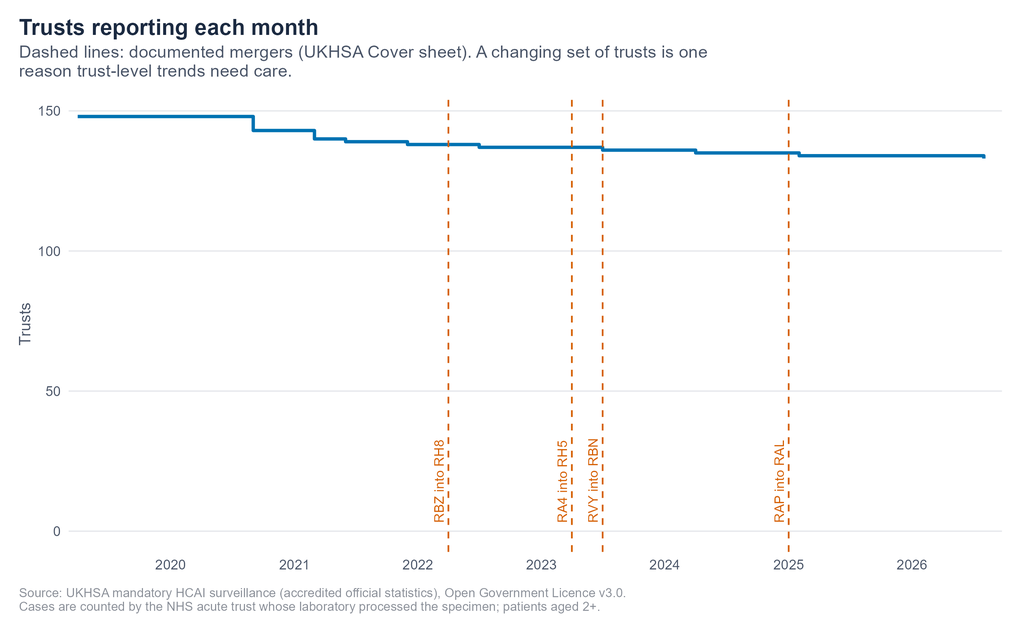

## Limitations

- **Counts, not rates.** Without bed-day denominators, differences between trusts mix infection risk with size, case-mix and testing practice.
- **Attribution.** Cases belong to the reporting laboratory’s trust, not necessarily where infection was acquired.
- **Changing trusts.** Mergers change which trusts exist; trust-level histories are not like-for-like across them. Regional and national series are more robust.
- **Revisions and provisional data.** Recent months are revised after release; real-time flags may disappear and past months may change.
- **COVID-19 distortion.** March 2020 to June 2021 is unrepresentative of normal seasonality; it is shaded throughout and excluded from model training.
- **Short baseline.** The consistent prior-trust-exposure definitions give about seven years; seasonal and trend estimates are correspondingly uncertain.
- **Thresholds are arbitrary.** A flag is a statistical prompt, never evidence of an outbreak, and no individual-level inference is possible from aggregated counts.

## Reproducibility

Everything on this page is regenerated by `Rscript run.R`. Source files, their retrieval dates and checksums are recorded in `data/raw/RETRIEVAL_LOG.csv`; documented data corrections are in `config/corrections.csv`. Report built 28 October 2026 17:30.